# HW 2

Matthew Fein

January 27, 2019

## HW 2

4.6.1 Import data

```r
library(ISLR)
admissions <- read.csv("admissions.csv", header = TRUE)
admissions$admit <- as.factor(admissions$admit)
```

Names of predictor variables and summary statistics. Admission to graduate school is the predicted variable.

```r
names(admissions)
```

```
## [1] "admit" "gre"   "gpa"   "rank"
```

```r
dim(admissions)
```

```
## [1] 400   4
```

```r
summary(admissions)
```

```
##  admit        gre             gpa             rank
##  0:273   Min.   :220.0   Min.   :2.260   Min.   :1.000
##  1:127   1st Qu.:520.0   1st Qu.:3.130   1st Qu.:2.000
##          Median :580.0   Median :3.395   Median :2.000
##          Mean   :587.7   Mean   :3.390   Mean   :2.485
##          3rd Qu.:660.0   3rd Qu.:3.670   3rd Qu.:3.000
##          Max.   :800.0   Max.   :4.000   Max.   :4.000
```

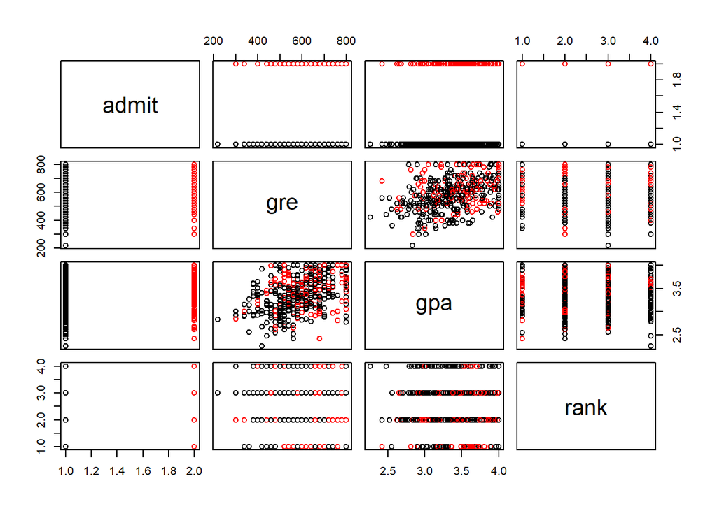

```r
pairs(admissions, col=admissions$admit)
```

```r
admissions$admit <- as.integer(admissions$admit)
cor(admissions)
```

```
##            admit        gre         gpa        rank
## admit  1.0000000  0.1844343  0.17821225 -0.24251318
## gre    0.1844343  1.0000000  0.38426588 -0.12344707
## gpa    0.1782123  0.3842659  1.00000000 -0.05746077
## rank  -0.2425132 -0.1234471 -0.05746077  1.00000000
```

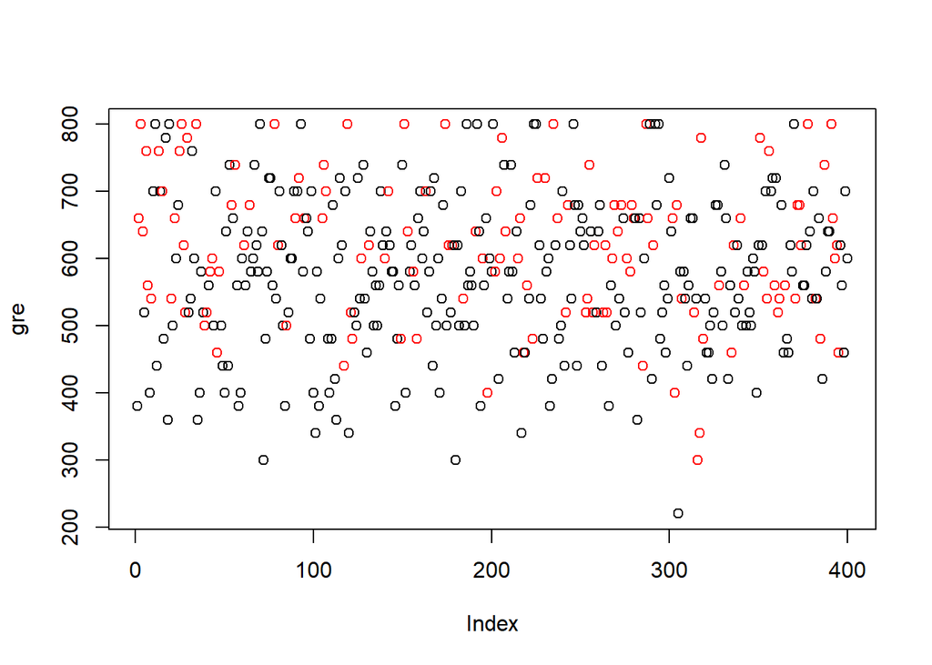

```r
attach(admissions)
admissions$admit<- as.factor(admissions$admit)
plot(gre, col= admissions$admit)
```

4.6.2- Logistic Regression

```r
glm.fits=glm(admit~gre+gpa+rank,data=admissions,family=binomial)
summary(glm.fits)
```

```
##
## Call:
## glm(formula = admit ~ gre + gpa + rank, family = binomial, data = admissions)
##
## Deviance Residuals:
##     Min       1Q   Median       3Q      Max
## -1.5802  -0.8848  -0.6382   1.1575   2.1732
##
## Coefficients:
##              Estimate Std. Error z value Pr(>|z|)
## (Intercept) -3.449548   1.132846  -3.045  0.00233 **
## gre          0.002294   0.001092   2.101  0.03564 *
## gpa          0.777014   0.327484   2.373  0.01766 *
## rank        -0.560031   0.127137  -4.405 1.06e-05 ***
## ---
## Signif. codes:  0 '***' 0.001 '**' 0.01 '*' 0.05 '.' 0.1 ' ' 1
##
## (Dispersion parameter for binomial family taken to be 1)
##
##     Null deviance: 499.98  on 399  degrees of freedom
## Residual deviance: 459.44  on 396  degrees of freedom
## AIC: 467.44
##
## Number of Fisher Scoring iterations: 4
```

```r
coef(glm.fits)
```

```
## (Intercept)         gre         gpa        rank
## -3.44954840  0.00229396  0.77701357 -0.56003139
```

```r
summary(glm.fits)$coef
```

```
##                Estimate  Std. Error   z value     Pr(>|z|)
## (Intercept) -3.44954840 1.132846009 -3.045029 2.326583e-03
## gre          0.00229396 0.001091839  2.101005 3.564052e-02
## gpa          0.77701357 0.327483878  2.372677 1.765968e-02
## rank        -0.56003139 0.127136989 -4.404945 1.058109e-05
```

All three predictors are significant- rank is negatively related to admission since 1 is best and 4 is worst.

```r
summary(glm.fits)$coef[,3]
```

```
## (Intercept)         gre         gpa        rank
##   -3.045029    2.101005    2.372677   -4.404945
```

```r
glm.probs=predict(glm.fits,type="response")
glm.probs[1:10]
```

```
##         1         2         3         4         5         6         7
## 0.1895527 0.3177807 0.7178136 0.1489492 0.0979542 0.3786785 0.3990411
##         8         9        10
## 0.2211761 0.2215203 0.5205019
```

```r
glm.pred=ifelse(glm.probs>0.5,"Admitted", "Denied")
glm.pred[glm.probs>.5]="Admitted"
attach(admissions)
table(glm.pred,admit)
```

```
##           admit
## glm.pred     1   2
##   Admitted  20  29
##   Denied   253  98
```

```r
(20+98)/400
```

```
## [1] 0.295
```

```r
detach(admissions)
```

```r
train <- admissions[1:300, ]
admissions.test <- admissions[301:400,]
dim(admissions.test)
```

```
## [1] 100   4
```

```r
glm.fits=glm(admit~gre+gpa+rank,data=train,family=binomial)
glm.probs=predict(glm.fits,train,type="response")
glm.pred=rep("Denied", 300)
glm.pred[glm.probs>.5]="Admitted"
table(glm.pred,train$admit)
```

```
##
## glm.pred     1   2
##   Admitted  18  25
##   Denied   190  67
```

```r
(18+67)/300
```

```
## [1] 0.2833333
```

```
##
## glm.pred    1  2
##   Admitted  3  1
##   Denied   62 34
```

```
## [1] 0.37
```

4.6.3 Linear Discriminant Analysis

```
## Call:
## lda(admit ~ gre + gpa + rank, data = train)
##
## Prior probabilities of groups:
##         1         2
## 0.6933333 0.3066667
##
## Group means:
##        gre      gpa     rank
## 1 573.4615 3.336587 2.706731
## 2 630.2174 3.498478 2.130435
##
## Coefficients of linear discriminants:
##               LD1
## gre   0.003657742
## gpa   1.015154592
## rank -0.777816954
```

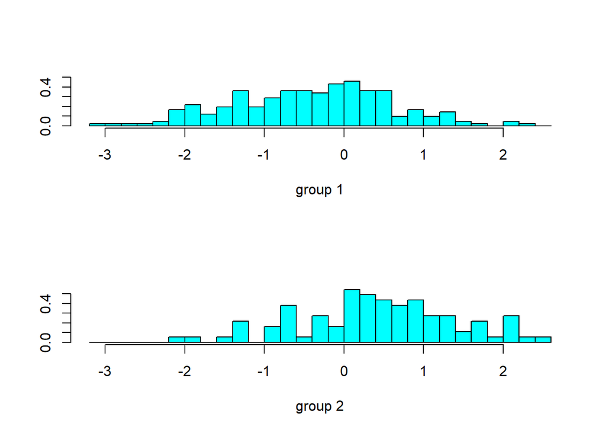

```
## [1] "class"     "posterior" "x"
```

```
##
## lda.class  1  2
##         1 60 26
##         2  5  9
```

```
## [1] 0.69
```

Accuracy on the test set improves to 69% when LDA is used, however, the assumption of equal distributions across clesses of outcome is violated.

```
## [1] 86
```

```
## [1] 14
```

```
##       301       302       303       304       305       306       307
## 0.6299695 0.7027148 0.7985080 0.4615504 0.9438219 0.8646891 0.5750221
##       308       309       310       311       312       313       314
## 0.6311697 0.7258442 0.8845766 0.6957658 0.5409115 0.6723235 0.8672201
##       315       316       317       318       319       320
## 0.8781255 0.8738146 0.8431551 0.7527317 0.8750803 0.5525014
```

```
##  [1] 1 1 1 2 1 1 1 1 1 1 1 1 1 1 1 1 1 1 1 1
## Levels: 1 2
```

```
## [1] 4
```

4.6.4 Quadratic Discriminant Analysis

```r
qda.fit=qda(admit~gre+gpa+rank,data=train)
qda.fit
```

```
## Call:
## qda(admit ~ gre + gpa + rank, data = train)
##
## Prior probabilities of groups:
##         1         2
## 0.6933333 0.3066667
##
## Group means:
##        gre      gpa     rank
## 1 573.4615 3.336587 2.706731
## 2 630.2174 3.498478 2.130435
```

```r
qda.class=predict(qda.fit,admissions.test)$class
table(qda.class,admissions.test$admit)
```

```
##
## qda.class  1  2
##         1 56 25
##         2  9 10
```

```r
mean(qda.class==admissions.test$admit)
```

```
## [1] 0.66
```

Using a QDA does not increase the model’s accuracy.

4.6.5 K-Nearest Neighbors

```r
library(class)
train.X=cbind(train$gre,train$gpa)
test.X=cbind(admissions.test$gre,admissions.test$gpa)
train.admit=train$admit
set.seed(1)
knn.pred=knn(train.X,test.X,train.admit,k=1)
table(knn.pred,admissions.test$admit)
```

```
##
## knn.pred  1  2
##        1 43 22
##        2 22 13
```

```r
(43+13)/100
```

```
## [1] 0.56
```

Our model is 56% accurate using a k of 1.

```r
knn.pred=knn(train.X,test.X,train.admit,k=3)
table(knn.pred,admissions.test$admit)
```

```
##
## knn.pred  1  2
##        1 50 18
##        2 15 17
```

```r
mean(knn.pred==admissions.test$admit)
```

```
## [1] 0.67
```

This improves to 67% with k of 3, however, we do not know what the contributions of each predictor variable are.

4.6.6 Standardizing data for KNN analysis

```r
standardized.X=scale(admissions[,-1])
var(admissions[,1])
```

```
## [1] 0.2172368
```

```r
var(admissions[,2])
```

```
## [1] 13344.07
```

```r
var(standardized.X[,1])
```

```
## [1] 1
```

```r
var(standardized.X[,2])
```

```
## [1] 1
```

Standardizing the variables provides us with equal variances

```
## [1] 0.46
```

```
## [1] 1
```

```
##         test.Y
## knn.pred  1  2
##        1 43 24
##        2 22 11
```

```
## [1] 0.54
```

With a k=1 the model is 54% accurate.

```r
knn.pred=knn(train.X,test.X,train.Y,k=3)
table(knn.pred,test.Y)
```

```
##         test.Y
## knn.pred  1  2
##        1 54 26
##        2 11  9
```

```r
(54+9/100)
```

```
## [1] 54.09
```

```r
knn.pred=knn(train.X,test.X,train.Y,k=5)
table(knn.pred,test.Y)
```

```
##         test.Y
## knn.pred  1  2
##        1 52 28
##        2 13  7
```

```r
(52+7)/100
```

```
## [1] 0.59
```

This improves with k=3 and is less accurate with k=5.

```
##         test.Y
## glm.pred  1  2
##      No  59 26
##      Yes  6  9
```

```
##         test.Y
## glm.pred  1  2
##      No  25 12
##      Yes 40 23
```

In comparison a logistic regression is 68% accurate with a threshold of 0.5. Adujstment to .25 decreased accuracy.